# Unidad Uno

John J Estrada Álvarez

2023-09-15

# Objetivo general

Cultivar el pensamiento lógico y deductivo resolviendoo problemas matemáticos que demandan la aplicación de leyes y principios de la lógica matemática. Esta actividad fomenta la capacidad de razonar con creatividad y precisión.

# Temas de la unidad uno

- Concepto de conjunto y sus propiedades básicas
- Conjuntos numéricos y su clasificación
- Concepto de distancia en la linea real
- Desigualdades y sus propiedades
- concepto de valor absoluto y sus propiedades
- Desigualdades con valor absoluto

## Teoría de conjuntos

### Definición de conjunto

Un **conjunto** es una colección bien definida de objetos, llamados sus elementos. Los conjuntos se simbolizan con letras mayúsculas $A$, $B$, $...$ Los objetos que componen el conjunto se denominan elementos y se denotan con letras minúsculas $a, b, ...$ [Tomado de (Zill & Dewar, 2012) pág $21$]

### Descripción por extensión y por comprensión

Para definir un **conjunto por extensión**, se enumeran todos sus elementos separándolos por comas y luego se encierran entre llaves.

Para escribir un **conjunto por comprensión** se elige un elemento arbitrario $x$ y se señala que cumple la propiedad $P(x)$. Finalmente, se encierra toda la expresión entre llaves. [Tomado de (Zill & Dewar, 2012) pág $22$] `

$$A=\{ x | x \ \ \text{cumple la propiedad} \ \ P(x) \}$$

### Igualdad de conjuntos

**Definición**

Diremos que dos conjutnos $A$ y $B$ son iguales si tienen los mismos elementos. Para indicar que $A$ y $B$ son iguales se escribe:[Tomado de (Zill & Dewar, 2012) pág $22$]

$$A=B$$

**Nota:**

Todo conjunto que posee un número finito de elementos; se llaman **conjuntos finitos**.

Todo conjunto que no tiene un número finito de elemenos se llaman **conjunto infinito**.

[Tomado de (Zill & Dewar, 2012) pág $23$]

### Cardinalidad de conjuntos

**Definición**

El número de elementos de un conjunto finito es lo que se llama la **cardinalidad** de dicho conjunto. La cardinalidad de un conjunto finito $A$ se denota por: [Tomado de (Zill & Dewar, 2012) pág $24$]

$$Card(A) \ \ \ \text{ó} \ \ \ |A|$$

### Conjuntos equipotentes

**Definición**

Dos conjuntos finitos $X$ y $Y$ se dicen ser **equipotentes** si tienen exactamente el mismo número de elementos. [Tomado de (Zill & Dewar, 2012) pág $24$]

### Conjunto vacío

**Definición**

Un conjunto se dice **vacío** si no posee elementos. El conjunto vacío se denota como:

$$\{ \} \ \ \ \text{ó} \ \ \ \Phi$$

### Conjunto universal

**Definición**

El conjunto **universal** se define como el conjunto que posee todos los elementos de todos los conjunots, y se denota como:[Tomado de (Zill & Dewar, 2012) pág $25$]

$$\text{Conjunto universal:} \ \ \ U$$

### Video sobe la historia de los diagramas de John Venn

Este video es una breve historia sobre el autor de los [diagramas de John Venn](https://app.visla.us/clip/1152501242652549120) en la teoría de conjuntos y en el idioma español

## Operaciones entre conjuntos

### Inclusión de conjuntos

**Definición**

Si cada elemento de un conjunto $A$ es también elemento de un conjunto $B$, entonces se dice que $A$ es un subconjunto de $B$. Se dice también que $A$ está contenido en $B$ o que $B$ contiene a $A$. La relación de subconjunto se denota como: [Tomado de (Zill & Dewar, 2012) pág $25$]

$$A \subset B \ \ \ \text{ó} \ \ \ B \supset A$$

$$A \subset B \ \ \ \text{si y sólo si } \ \ \ \ \text{Para todo }
x, \ \ \ \ \ x \in A \ \ \ \text{entonces } \ \ \ x \in B$$

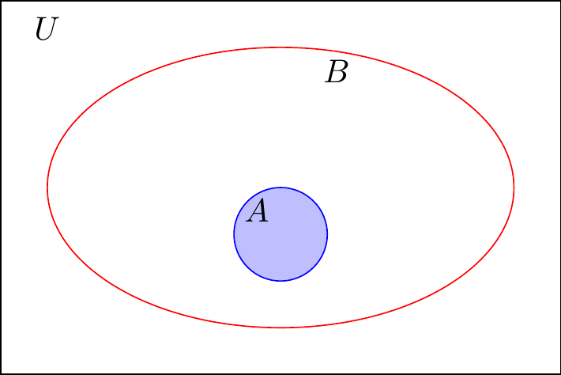

Inclusión de conjuntos

### Unión de conjuntos

**Definición**

La unión de dos conjuntos $A$ y $B$ consta de todos los elementos que pertenecen a $A$ o a $B$. La unión de $A$ y $B$ se denota por $A \cup B$. [Tomado de (Zill & Dewar, 2012) pág $31$]

$$A \cup B = \{ x | x \in A \ \text{o} \ x \in B\}$$

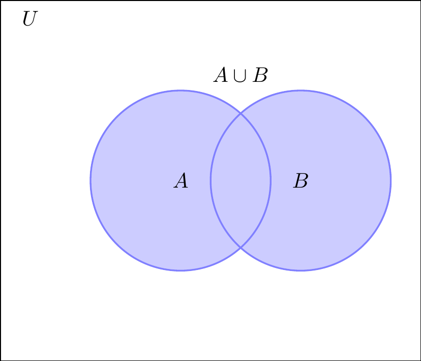

Unión de conjuntos

### Video unión entre conjuntos

Link para ver y escuchar el concepto de [unión entre dos conjuntos](https://app.visla.us/clip/1152205974044434432).

#### Propiedades de la Unión

$$\begin{matrix}
(a) & A \cup B = B \cup A & \text{propiedad conmutativa} \\
(b) & (A \cup B) \cup C = A \cup (B \cup C) & \text{propiedad
asociativa} \\
(c) & A \cup \Phi = A & \text{propiedad de la existencia para
la identidad} \\
(d) & A \cup U = U & \text{propiedad de la existencia del
conjunto absorbente}
\end{matrix}$$

### Intersección de conjuntos

**Definición**

La intersección de dos conjuntos $A$ y $B$ consta de todos los elementos que pertenecen a $A$ y a $B$. La intersección de $A$ y $B$ se denota por $A \cap B$. [Tomado de (Zill & Dewar, 2012) pág $30$]

$$A \cap B = \{ x | x \in A \ \text{y} \ x \in B\}$$

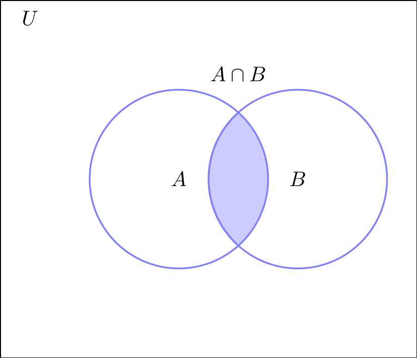

Intersección de conjuntos

#### Propiedades de la Intersección

$$\begin{matrix}
(a) & A \cap B = B \cap A & \text{propiedad conmutativa} \\
(b) & (A \cap B) \cap C = A \cap (B \cap C) & \text{propiedad
asociativa} \\
(c) & A \cap U = A & \text{propiedad de la existencia para la
identidad} \\
(d) & A \cap \Phi = \Phi & \text{propiedad de la existencia del
conjunto absorbente}
\end{matrix}$$

#### Propiedades de la unión y la intersección

$$\begin{matrix}
(a) & A \cup (B \cap C) = (A \cup B) \cap (A \cup C) &
\text{prop dist de la unión respecto a la intersección} \\
(b) & A \cap (B \cup C) = (A \cap B) \cup (A \cap C) &
\text{prop dist de la intersección respecto a la unión}
\end{matrix}$$

### Diferencia entre dos conjuntos

**Definición**

La diferencia de dos conjuntos $A$ y $B$ consta de todos los elementos que pertenecen a $A$ y no pertenecen a $B$. La diferencia de $A$ y $B$ se denota por $A - B$. [Tomado de (Zill & Dewar, 2012) pág $34$]

$$A - B = \{ x | x \in A \ \text{y} \ x \notin B\}$$

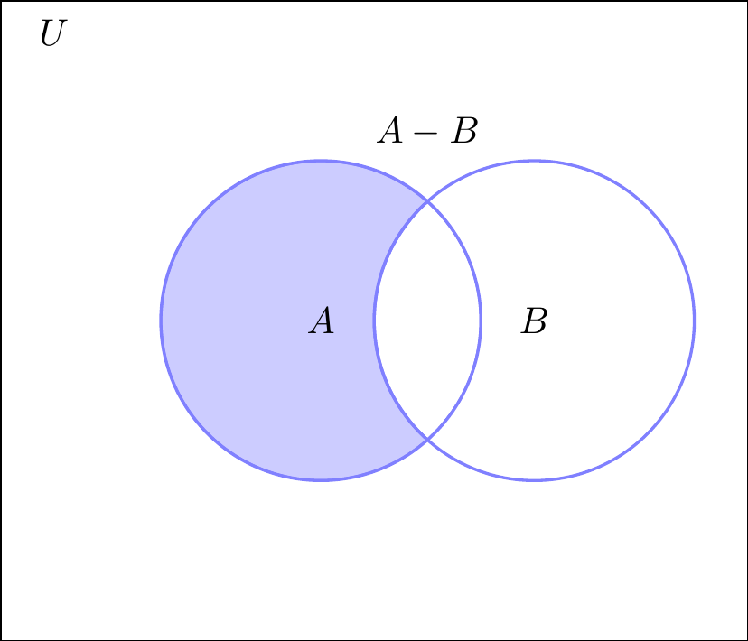

Diferencia de conjuntos

$$B - A = \{ x | x \in B \ \text{y} \ x \notin A\}$$

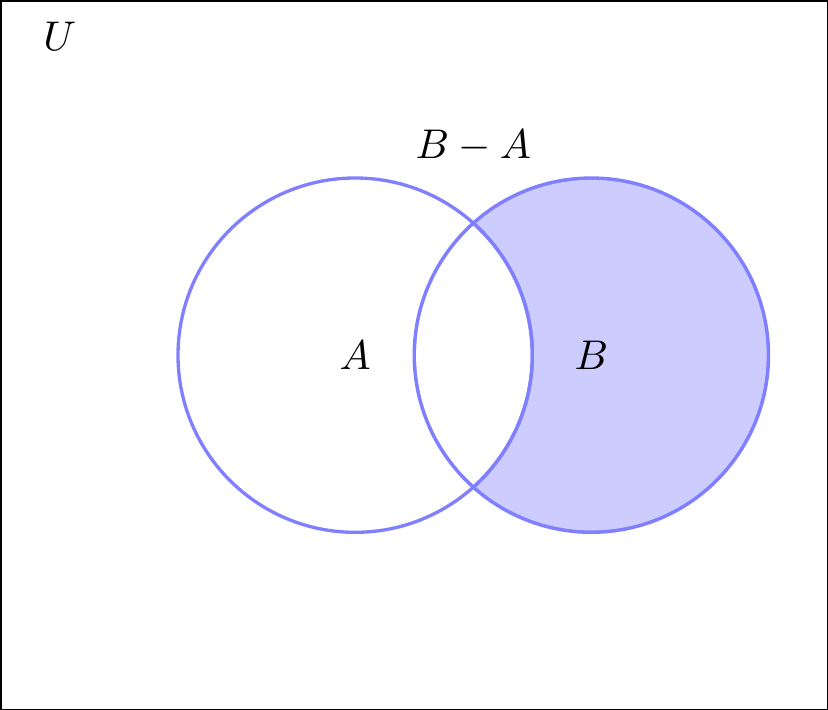

Diferencia de conjuntos

### Complemento de un conjunto

**Definición**

El complemento de un conjunto $A$ consta de todos los elementos del universo $U$, y que no pertenecen a $A$. El complemento de $A$ se denota por $A^{c}$. [Tomado de (Zill & Dewar, 2012) pág $34$]

$$A'=A^{c} = \{ x | x \notin A \}$$

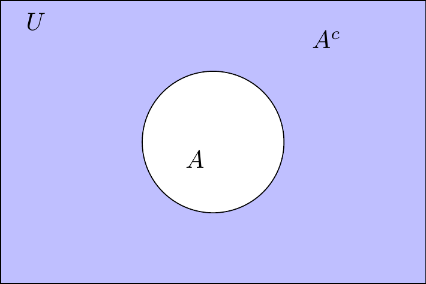

Complemento de un conjunto

### Diferencia simétrica de dos conjuntos

**Definición**

La diferencia simétrica entre dos conjuntos $A$ y $B$ se define como el conjunto de todos los elementos del universo $U$, que pertenecen a $(A-B) \cup (B-A)$.

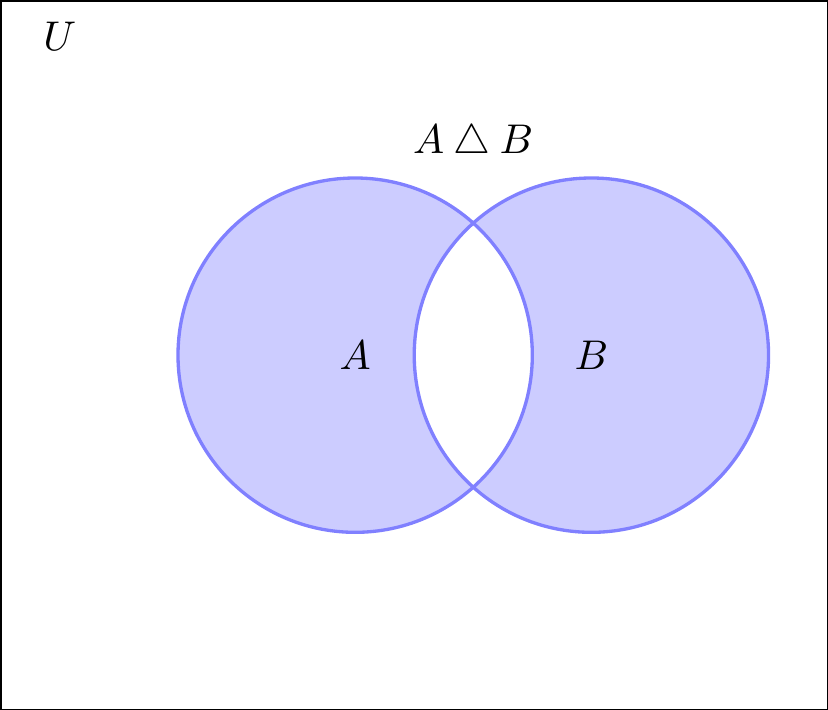

Diferencia simétrica de conjuntos

### Propiedades del algebra de conjuntos

$$\begin{equation}
\begin{matrix}
\text{Leyes de idemponentes} & &\\
(1a) \ \ A \cup A = A & (1b) \ \ A \cap A = A &\\
& & &\\
\text{Leyes asociativas} & &\\
(2a) \ \ (A \cup B) \cup C = A \cup (B \cup C) & (2b) \ \ (A \cap
B) \cap C = A \cap (B \cap C) &\\
& & &\\
\text{Leyes conmutativas} & &\\
(3a) \ \ A \cup B = B \cup A & (3b) \ \ A \cap B = B \cap A &\\
& & &\\
\text{Leyes distributivas} & &\\
(4a) \ \ A \cup (B \cap C) = (A \cup B) \cap (A \cup C) & (4b) \ \ A
\cap (B \cup C) = (A \cap B) \cup (A \cap C) &\\
& & &\\
\text{Leyes de identidad y absorción} & &\\
(5a) \ \ A \cup \Phi = A & (5b) \ \ A \cap U = A &\\
(6a) \ \ A \cup U = U & (6b) \ \ A \cap \Phi = \Phi &\\
& & &\\
\text{Ley involutiva} & &\\
(7a) \ \ (A^{c})^{c}=A & &\\
& & &\\
\text{Leyes del complementario} & &\\
(8a) \ \ A \cup A^{c} = U & (8b) \ \ A \cap A^{c} = \Phi &\\
(9a) \ \ U^{c} = \Phi & (9b) \ \ {\Phi}^{c} = U \\
& & &\\
\text{Leyes de De Morgan} & &\\
(10a) \ \ (A \cup B)^{c} = A^{c} \cap B^{c} & (10b) \ \ (A \cap
B)^{c} = A^{c}\cup B^{c}
\end{matrix}
\end{equation}$$

## Actividad Geogebra: Operaciones con conjuntos

A partir de los conceptos anteriores seleccionar $A\cup B$, $A\cap B$ en la herramienta geogebra y determinar:

- si $A \cup B = A\cap B$
- si $A \cup B = C\cap B$
- si $A \cup B = C - A$
- si $A \cup B = B - C$

Esta es una aplicación que muestra graficamente las operaciones entre tres conjuntos, el Autor:LikitMaths (https://www.geogebra.org/m/QWS4wDtE) las elaboro usando geogebra.

## Ejemplo1 - Po Shen Loh

Si conocemos que el cardinal del conjunto universal es 34, podemos deducir una ecuación cuadratica que surge al igualar la cardinalidad a partir de dos formas.

$$\text{información que proporciona el enunciado } \ \ 34 = 7x^2+21x+6 \ \
\text{cardinalidad al sumar cada uno de los cardinales en la figura.}$$

Y usando la técnica (ó [métodfo de Po Shen Loh](https://jestradacasasept2022.shinyapps.io/MetodoPoShenLohV3/)) obtener:

- El cardinal de $B - A$
- El cardinal de $C - B$

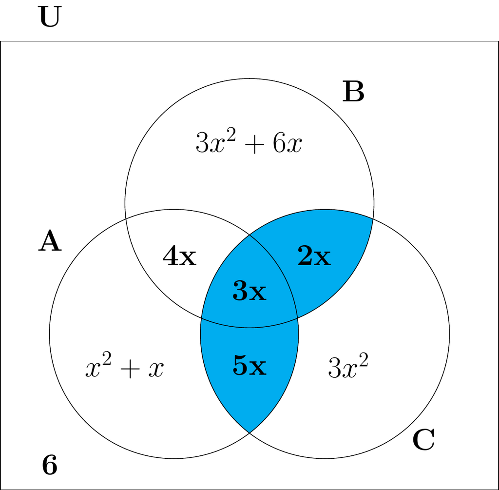

Figura 1: ejemplo de operaciones entre conjuntos

## Ejemplo2

De un grupo de 80 personas de las cuales se tiene información de que 27 leían la revista A, pero no leían la revista B; 26 leían la revista B, pero no la C; 19 leían C pero no A; 2 las tres revistas mencionadas. ¿Cúantos preferían otras revistas?

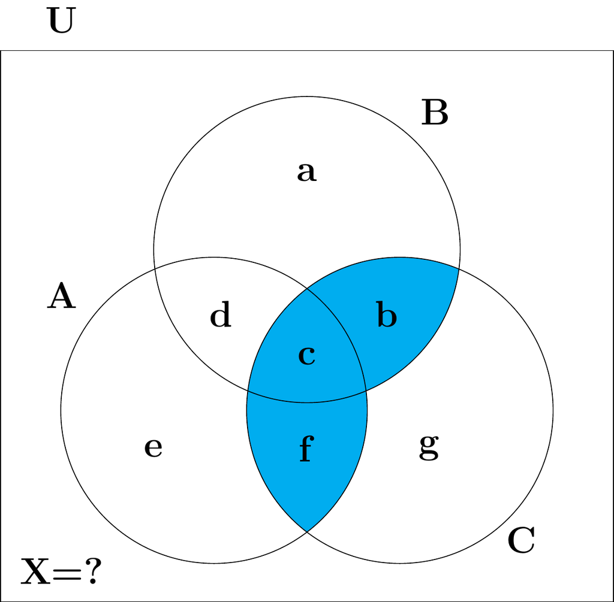

Figura 2: ejemplo de operaciones entre conjuntos

A partir de la figura 2, y usando los conceptos de cardinalidad para un conjunto se logra obtener el sistema de ecuaciones:

$$\begin{equation}
\begin{split}
(1)\ \ \ 80 & = & \ \ a + b + c + d + e + f + g + X \\
(2)\ \ \ 27 & = & \ \ e + f \ \ \ \text{leían la revista A pero
no la B}\\
(3)\ \ \ 26 & = & \ \ a + d \ \ \ \text{leían la revista B pero
no la C}\\
(4)\ \ \ 19 & = & \ \ b + g \ \ \ \text{leían la revista C pero
no la A}\\
(5)\ \ \ 2 & = & \ \ c \ \ \ \text{leían las tres revistas}\\
& & \text{sustituyendo } (2) , (3), (4), (5) \ \ \text{en } \ \
(1) \ \ \text{se tiene:}\\
80 & = & \ \ (e + f) + (a + d) + (b + g) + c + X\\
80 & = & \ \ 27 + 26 + 19 + 2 + X\\
80 & = & \ \ 74 + X\\
X & = & \ \ 80 - 74\\
X & = & \ \ 6
\end{split}
\end{equation}$$

**Respuesta:** Son 6 el número de personas que preferían leer otras revistas.

## Actividad evaluativa para el primer tema de la unidad uno

[interactive chart not shown]

# Referencias

Zill, D. G., & Dewar, J. M. (2012). *Algebra, trigonometria y geometria analitica.* McGraw Hill.